# Analysis for Harming Behaviors

George Dewey

2022-09-22

This document will go through the analysis of punishment behavior and related patterns in two network-based social experiments.

Notes: This document will be an updated version of the document previously worked on titled “Evolution of Peace in Experimental Social Networks”.

## Summary of Previous Work and Objectives

Previously, our analysis resulted in two main findings: 1) that decision time and type of behavior are related, where choosing punishment results in longer decision times compared to either non-punishing (cooperation or defection) behavior and 2) that there is a threshold in players’ local network, that when exceeded, results in a higher propensity to choose to punish.

The objective of this document is to concretely establish the validity of finding 1 and to further explore the mechanisms resulting in finding 2).

## Load data and packages

```r
mean1 = function(x) {mean(x, na.rm = TRUE)}

library(tidyverse)
library(lme4)
library(magrittr)
library(igraph)

load("~/Documents/Projects/harming_esn/Data/harmdata.Rdata") #harmdata
load("~/Documents/Projects/harming_esn/Data/harming_jsons/ldata4_0316X.Rdata") #ldata4
load("~/Documents/Projects/harming_esn/Data/ndata_individual.Rdata") #ndata1
load("~/Documents/Projects/harming_esn/Data/data1.Rdata") #data1
```

## Show distriubtion of decision time

```r
# Isolate the time data
dt_data = data1 %>%
  group_by(superid) %>%
  summarize(mean_dt = mean1(behaviorTime),
            mean_log_dt = mean1(log(behaviorTime)))

# Filter decision times by behavior type and merge
dt_coop = data1 %>%
  group_by(superid) %>%
  filter(behavior_coop == 1) %>%
  summarize(mean_dt_coop = mean1(behaviorTime),
            mean_log_dt_coop = mean1(log(behaviorTime)))

dt_def = data1 %>%
  group_by(superid) %>%
  filter(behavior_defect == 1) %>%
  summarize(mean_dt_defect = mean1(behaviorTime),
            mean_log_dt_defect = mean1(log(behaviorTime)))

dt_punish = data1 %>%
  group_by(superid) %>%
  filter(behavior_punish == 1) %>%
  summarize(mean_dt_punish = mean1(behaviorTime),
            mean_log_dt_punish = mean1(log(behaviorTime)))

dt_non_punish = data1 %>%
  group_by(superid) %>%
  filter(behavior_punish == 0) %>%
  summarize(mean_dt_nonpunish = mean1(behaviorTime),
            mean_log_dt_nonpunish = mean1(log(behaviorTime)))

dt_data_by_behavior = left_join(dt_coop, dt_def, by = "superid") %>%
  left_join(dt_punish, by = "superid") %>%
  left_join(dt_non_punish, by = "superid")
```

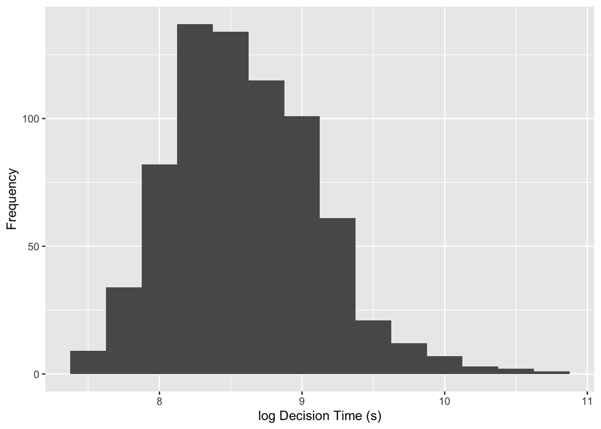

```r
# Show distribution of all decision times
dt_data %>%
  ggplot() +
  geom_histogram(aes(x = mean_log_dt), binwidth = 0.25) +
  xlab("log Decision Time (s)")+
  ylab("Frequency")
```

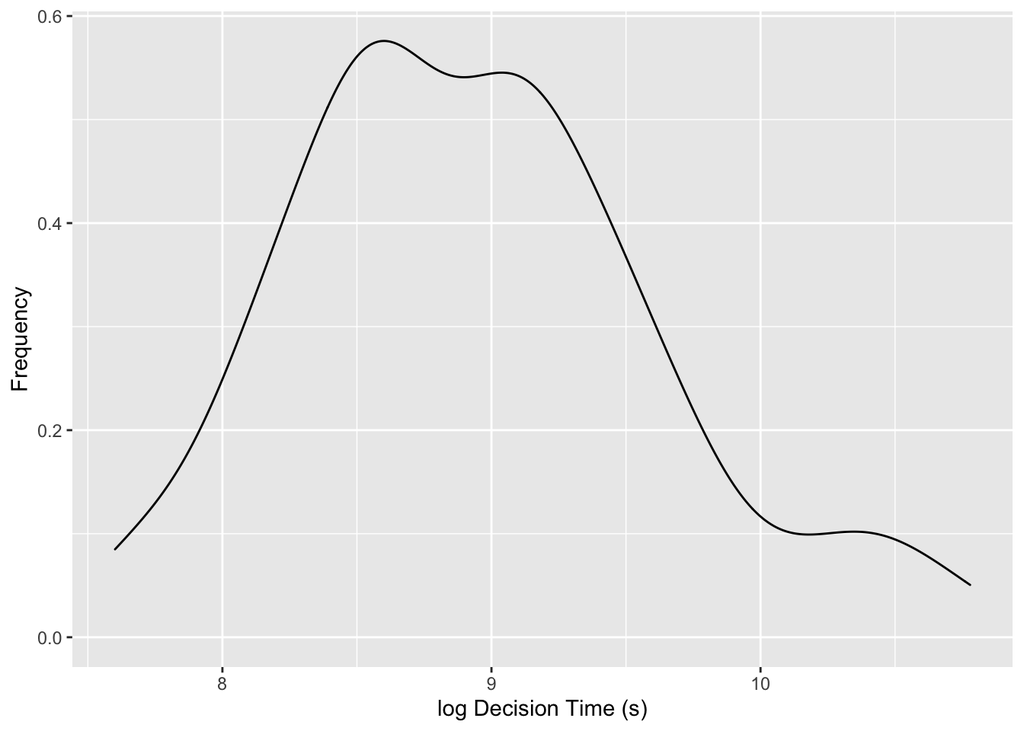

```r
# Show distribution of decision times for punish/non-punish, aggregated by individual

## Punish times
dt_data_by_behavior %>%
  ggplot() +
  geom_density(aes(x = mean_log_dt_punish)) +
  xlab("log Decision Time (s)")+
  ylab("Frequency")
```

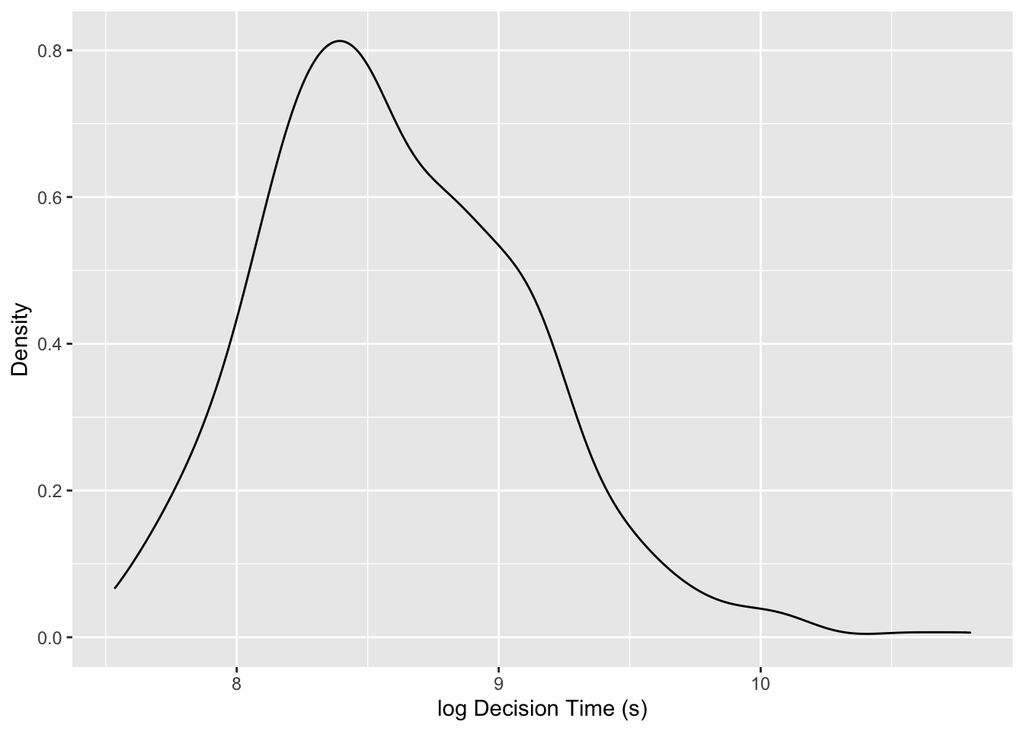

```r
## Nonpunish times
dt_data_by_behavior %>%
  ggplot() +
  geom_density(aes(x = mean_log_dt_nonpunish)) +
  xlab("log Decision Time (s)") +
  ylab("Density")
```

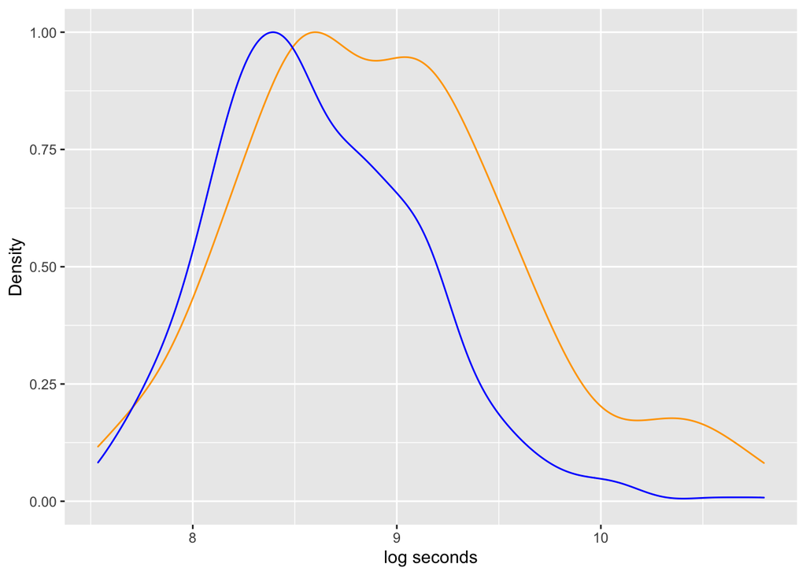

```r
## Together
dt_data_by_behavior %>%
  ggplot() +
  geom_density(aes(x = mean_log_dt_punish, y = ..scaled..), color = "orange") +
  geom_density(aes(x = mean_log_dt_nonpunish, y = ..scaled..), color = "blue")+
  xlab("log seconds")+
  ylab("Density")
```

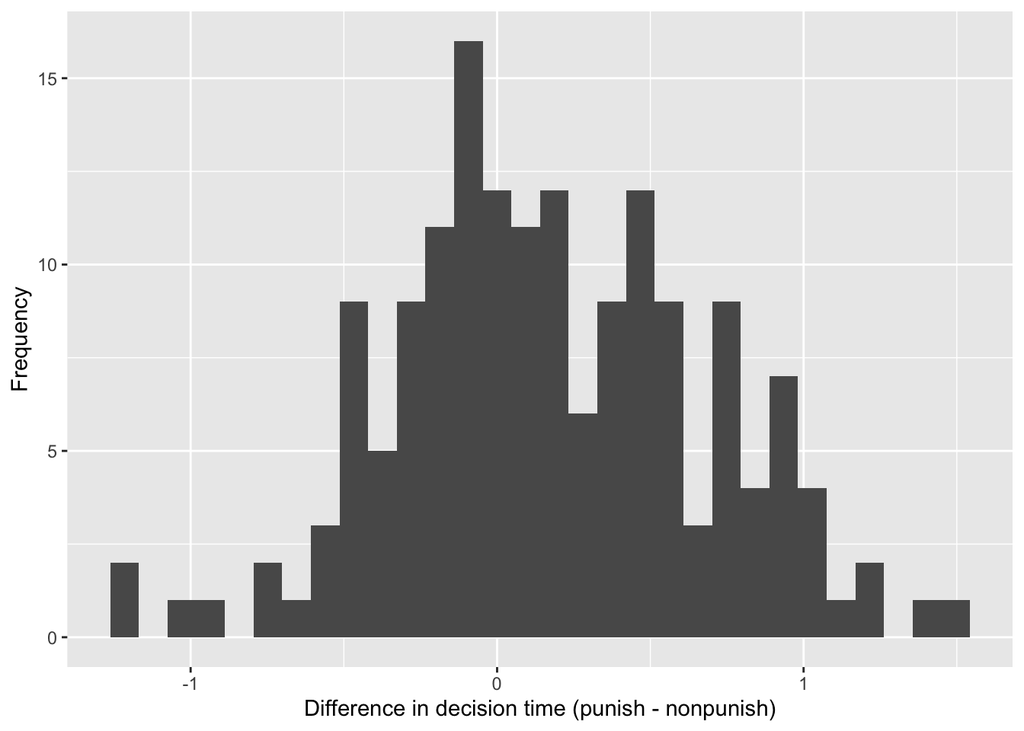

```r
# Show distribution of the difference between punish and nonpunish choices, by individual (paired differences)
dt_data_by_behavior %>%
  select(mean_log_dt_punish, mean_log_dt_nonpunish) %>%
  mutate(dt_diff = mean_log_dt_punish - mean_log_dt_nonpunish) %>%
  filter(is.na(dt_diff) == 0) %>%
  ggplot() +
  geom_histogram(aes(x = dt_diff)) +
  xlab("Difference in decision time (punish - nonpunish)") +
  ylab("Frequency")
```

## Understanding behavioral contributions to peace

```r
#### Network Analysis for Peace

## We define peace as having no punishment in at least 5 (or 3?) consecutive rounds

#### Part 1 - Game level analysis ####
# First checking how many rounds have a punishment choice
peace_rounds = NULL
punish_rounds = NULL
for(i in 1:50){
  tmp = harmdata %>% filter(game == i, round !=0) %>% group_by(round) %>%
    tally(behavior_punish) %>% group_by(n) %>% summarize(round_count = n())
  peace_rounds = c(peace_rounds,
                   sum(tmp %>% filter(n == 0) %>% pull(round_count)))
  punish_rounds = c(punish_rounds,
                    sum(tmp %>% filter(n != 0) %>% pull(round_count)))
}
sum(peace_rounds) #377 rounds with no punish choice
```

```
## [1] 377
```

```r
sum(punish_rounds) #373 rounds with at least 1 punish choice
```

```
## [1] 373
```

```r
## The balance between peaceful and non-peaceful rounds is evident. Makes sense given the small range of behavioral choices? (need to find theory??)

tmp = harmdata %>% filter(game == 1, round !=0) %>% group_by(round) %>% tally(behavior_punish) %>% pull(n)

subseq_check <- function(x,y) grepl(toString(y),toString(x),fixed = TRUE)
subseq_check(tmp, c("0", "0", "0", "0", "0"))
```

```
## [1] TRUE
```

```r
peace_str = c("0", "0", "0", "0", "0")

tmp = c(1, 2, 3, 4, 5)

peace_games = NULL
war_games = NULL
for(i in 1:50){
  tmp = harmdata %>% filter(game == i, round !=0) %>% group_by(round) %>%
    tally(behavior_punish) %>% pull(n)
  if(subseq_check(tail(tmp, 5), peace_str) == T){
    peace_games = c(peace_games, i)
  } else {
    war_games = c(war_games, i)
  }
}
```

```r
length(peace_games) #14 games had peace (last 5 rounds had no punishment)
```

```
## [1] 14
```

## Create a heatmap for the number of punishments in each round of peaceful games

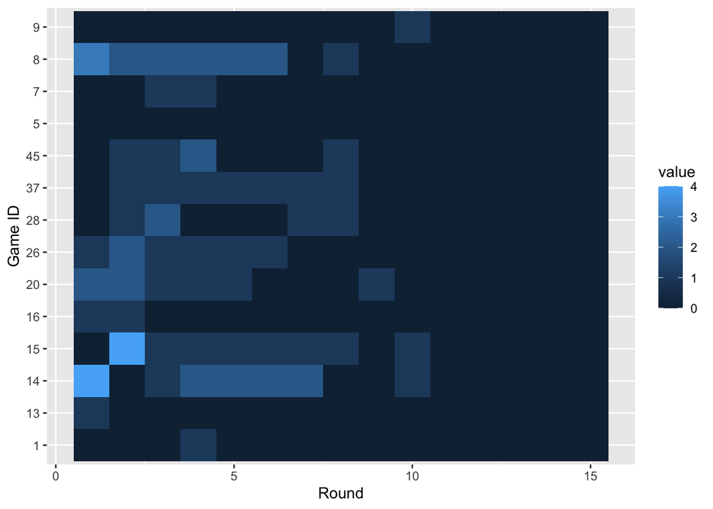

```r
punish_counts = NULL
for(i in peace_games){
  tmp = harmdata %>% filter(game == i, round !=0) %>% group_by(round) %>%
    tally(behavior_punish) %>% pull(n)
  punish_counts = cbind(punish_counts, tmp)
}
punish_counts = as.data.frame(punish_counts)
names(punish_counts) = as.numeric(as.character(peace_games))

punish_counts %>%
  rownames_to_column() %>%
  gather(colname, value, -rowname) %>%
  ggplot(aes(x = as.numeric(rowname), y = colname, fill = value)) +
  geom_tile() +
  xlab("Round") + ylab("Game ID")
```

# Calculate the number of punishments per game and create a visual (originally heatmap_behavior.R)

```r
# get the number of punishments per game
pun_counts = harmdata %>%
  group_by(game) %>%
  tally(behavior_punish) %>%
  rename(punishments = n)

# get the number of punishments per game by round
harmdata %>%
  group_by(game, round) %>%
  tally(behavior_punish)
```

```
## # A tibble: 800 × 3
## # Groups:   game [50]
##     game round     n
##    <int> <dbl> <dbl>
##  1     1     0     0
##  2     1     1     0
##  3     1     2     0
##  4     1     3     0
##  5     1     4     1
##  6     1     5     0
##  7     1     6     0
##  8     1     7     0
##  9     1     8     0
## 10     1     9     0
## # … with 790 more rows
## # ℹ Use `print(n = ...)` to see more rows
```

```r
names(harmdata)
```

```
##  [1] "superid"                  "gameID"
##  [3] "game"                     "scoreA"
##  [5] "scoreB"                   "percentA"
##  [7] "showScore"                "round"
##  [9] "satisfaction.1"           "behavior_coop"
## [11] "behavior_defect"          "behavior_punish"
## [13] "e_payoff"                 "cPayoffS"
## [15] "behaviorTime"             "gender"
## [17] "age"                      "ipAddress"
## [19] "e_behaviorTime"           "payoff"
## [21] "cumulativePayoff"         "e_cumulativePayoff"
## [23] "degree"                   "e_degree"
## [25] "e_satisfaction"           "rate_rich"
## [27] "local_gini"               "local_avg_wealth"
## [29] "local_avg_stdwealth"      "local_med_wealth"
## [31] "prev_local_rate_coop"     "local_rate_coop"
## [33] "prev_local_rate_defect"   "local_rate_defect"
## [35] "prev_local_rate_punish"   "local_rate_punish"
## [37] "rank"                     "rel_rank"
## [39] "rel_wealth"               "initial_coop"
## [41] "initial_defect"           "initial_punish"
## [43] "initial_local_gini"       "initial_local_avg_wealth"
## [45] "initial_degree"           "initial_score"
## [47] "happ"                     "PosWealth"
## [49] "WealthLevel"              "country"
## [51] "country_3cat"
```

```r
netdata = harmdata %>%
  group_by(game) %>%
  select(superid, game, round, showScore, behavior_coop, behavior_defect,
         behavior_punish, payoff, behaviorTime, degree, rate_rich,
         local_gini, initial_coop, initial_defect, initial_punish, initial_local_gini,
         initial_degree, happ, WealthLevel,PosWealth, country) %>%
  arrange(game, round, superid) %>%
  mutate(peace_game = ifelse(game %in% peace_games, 1, 0))  %>%
  summarize(showScore = mean(showScore),
            n = n(),
            mean_deg = mean1(degree),
            mean_init_deg = mean1(initial_degree),
            mean_behaviorTime = mean1(behaviorTime),
            mean_payoff = mean1(payoff),
            sum_cum_payoff = sum(payoff, na.rm = T),
            prop_punish = mean1(behavior_punish),
            sum_punish = sum(behavior_punish),
            prop_coop = mean1(behavior_coop),
            sum_coop = sum(behavior_coop),
            init_coop = mean1(initial_coop),
            init_punish = mean1(initial_punish),
            mean_gini = mean1(initial_local_gini),
            mean_posWealth = mean1(PosWealth),
            peace_game = mean1(peace_game))

netdata1 = left_join(netdata, pun_counts, by = "game")
```

## Understanding what this aggregate dataframe `netdata` is

```r
# Netdata is the data aggregated at the game level
# numeric values are averaged across rounds by game
# what other aggregate data can I use?

# Regressions are thus aggregations of aggregations - viable?

netdata
```

```
## # A tibble: 50 × 17
##     game showScore     n mean_…¹ mean_…² mean_…³ mean_…⁴ sum_c…⁵ prop_…⁶ sum_p…⁷
##    <int>     <dbl> <int>   <dbl>   <dbl>   <dbl>   <dbl>   <dbl>   <dbl>   <dbl>
##  1     1         0   160    5.56    4.8    4940    230.    34450 0.00625       1
##  2     2         0   171    4.69    3.09   7836.   175     28000 0.0292        5
##  3     3         0   160    3.45    2      7607.    75     11250 0.0625       10
##  4     4         0   170    4.46    3.14  10179.   132.    20650 0.0471        8
##  5     5         0   146    5.96    3.75   4046.   263.    35450 0             0
##  6     6         0   136    3.43    2.65   5347.   125.    15650 0.0588        8
##  7     7         0   126    2.8     3.63   7191.    60.3    7000 0.0159        2
##  8     8         0   197    4.98    3.85   7283.   132.    24200 0.0711       14
##  9     9         0   200    5.47    4.36   6738.   197.    36900 0.00500       1
## 10    10         0   171    4.76    3.95  12187.   165.    25800 0.0409        7
## # … with 40 more rows, 7 more variables: prop_coop <dbl>, sum_coop <dbl>,
## #   init_coop <dbl>, init_punish <dbl>, mean_gini <dbl>, mean_posWealth <dbl>,
## #   peace_game <dbl>, and abbreviated variable names ¹mean_deg, ²mean_init_deg,
## #   ³mean_behaviorTime, ⁴mean_payoff, ⁵sum_cum_payoff, ⁶prop_punish,
## #   ⁷sum_punish
## # ℹ Use `print(n = ...)` to see more rows, and `colnames()` to see all variable names
```

## Regression models using the aggregate data

```r
## Model 0 - wealth visibility only
m0 = glm(peace_game ~ showScore, data = netdata)
summary(m0)
```

```
##
## Call:
## glm(formula = peace_game ~ showScore, data = netdata)
##
## Deviance Residuals:
##    Min      1Q  Median      3Q     Max
##  -0.40   -0.40   -0.16    0.60    0.84
##
## Coefficients:
##             Estimate Std. Error t value Pr(>|t|)
## (Intercept)  0.40000    0.08832   4.529 3.92e-05 ***
## showScore   -0.24000    0.12490  -1.922   0.0606 .
## ---
## Signif. codes:  0 '***' 0.001 '**' 0.01 '*' 0.05 '.' 0.1 ' ' 1
##
## (Dispersion parameter for gaussian family taken to be 0.195)
##
##     Null deviance: 10.08  on 49  degrees of freedom
## Residual deviance:  9.36  on 48  degrees of freedom
## AIC: 64.115
##
## Number of Fisher Scoring iterations: 2
```

```r
# Question - why are peace and wealth visibility related?

xtabs(~peace_game + showScore, netdata) # peaceful games are mostly invisible wealth
```

```
##           showScore
## peace_game  0  1
##          0 15 21
##          1 10  4
```

## What factors link peaceful games (i.e. waning of punishment frequency in later rounds) to wealth visibilty?

```r
# Degree measures
m1.1 = glm(peace_game ~ showScore + mean_deg +  mean_init_deg, data = netdata1)
summary(m1.1)
```

```
##
## Call:
## glm(formula = peace_game ~ showScore + mean_deg + mean_init_deg,
##     data = netdata1)
##
## Deviance Residuals:
##     Min       1Q   Median       3Q      Max
## -0.5720  -0.3102  -0.1600   0.4968   0.8672
##
## Coefficients:
##                Estimate Std. Error t value Pr(>|t|)
## (Intercept)    0.153758   0.216004   0.712    0.480
## showScore     -0.251677   0.126701  -1.986    0.053 .
## mean_deg       0.047789   0.063782   0.749    0.458
## mean_init_deg -0.002018   0.067460  -0.030    0.976
## ---
## Signif. codes:  0 '***' 0.001 '**' 0.01 '*' 0.05 '.' 0.1 ' ' 1
##
## (Dispersion parameter for gaussian family taken to be 0.1965156)
##
##     Null deviance: 10.0800  on 49  degrees of freedom
## Residual deviance:  9.0397  on 46  degrees of freedom
## AIC: 66.374
##
## Number of Fisher Scoring iterations: 2
```

```r
netdata1
```

```
## # A tibble: 50 × 18
##     game showScore     n mean_…¹ mean_…² mean_…³ mean_…⁴ sum_c…⁵ prop_…⁶ sum_p…⁷
##    <int>     <dbl> <int>   <dbl>   <dbl>   <dbl>   <dbl>   <dbl>   <dbl>   <dbl>
##  1     1         0   160    5.56    4.8    4940    230.    34450 0.00625       1
##  2     2         0   171    4.69    3.09   7836.   175     28000 0.0292        5
##  3     3         0   160    3.45    2      7607.    75     11250 0.0625       10
##  4     4         0   170    4.46    3.14  10179.   132.    20650 0.0471        8
##  5     5         0   146    5.96    3.75   4046.   263.    35450 0             0
##  6     6         0   136    3.43    2.65   5347.   125.    15650 0.0588        8
##  7     7         0   126    2.8     3.63   7191.    60.3    7000 0.0159        2
##  8     8         0   197    4.98    3.85   7283.   132.    24200 0.0711       14
##  9     9         0   200    5.47    4.36   6738.   197.    36900 0.00500       1
## 10    10         0   171    4.76    3.95  12187.   165.    25800 0.0409        7
## # … with 40 more rows, 8 more variables: prop_coop <dbl>, sum_coop <dbl>,
## #   init_coop <dbl>, init_punish <dbl>, mean_gini <dbl>, mean_posWealth <dbl>,
## #   peace_game <dbl>, punishments <dbl>, and abbreviated variable names
## #   ¹mean_deg, ²mean_init_deg, ³mean_behaviorTime, ⁴mean_payoff,
## #   ⁵sum_cum_payoff, ⁶prop_punish, ⁷sum_punish
## # ℹ Use `print(n = ...)` to see more rows, and `colnames()` to see all variable names
```

```r
m1_full = glm(peace_game ~ showScore + mean_deg +  mean_init_deg + mean_behaviorTime + mean_payoff + sum_cum_payoff + prop_punish + prop_coop + sum_punish + sum_coop + init_punish + init_coop + mean_gini + mean_posWealth, data = netdata1)

summary(m1_full) # only prop_punish; more punish -> less peace. makes sense.
```

```
##
## Call:
## glm(formula = peace_game ~ showScore + mean_deg + mean_init_deg +
##     mean_behaviorTime + mean_payoff + sum_cum_payoff + prop_punish +
##     prop_coop + sum_punish + sum_coop + init_punish + init_coop +
##     mean_gini + mean_posWealth, data = netdata1)
##
## Deviance Residuals:
##      Min        1Q    Median        3Q       Max
## -0.72131  -0.20985   0.01834   0.18557   0.70605
##
## Coefficients:
##                     Estimate Std. Error t value Pr(>|t|)
## (Intercept)        2.147e+00  7.672e-01   2.798  0.00829 **
## showScore         -1.130e-01  1.273e-01  -0.888  0.38070
## mean_deg          -1.475e-01  1.266e-01  -1.165  0.25191
## mean_init_deg      2.748e-02  8.663e-02   0.317  0.75297
## mean_behaviorTime -4.840e-05  3.479e-05  -1.391  0.17293
## mean_payoff        6.597e-03  5.322e-03   1.239  0.22344
## sum_cum_payoff    -6.356e-06  1.671e-05  -0.380  0.70590
## prop_punish       -1.450e+01  7.318e+00  -1.981  0.05547 .
## prop_coop         -2.060e+00  1.732e+00  -1.189  0.24247
## sum_punish         2.488e-02  3.157e-02   0.788  0.43597
## sum_coop           2.965e-03  9.100e-03   0.326  0.74652
## init_punish        1.320e+00  1.079e+00   1.223  0.22947
## init_coop         -9.478e-03  5.984e-01  -0.016  0.98745
## mean_gini         -2.675e-01  9.459e-01  -0.283  0.77898
## mean_posWealth    -2.472e-04  4.386e-04  -0.564  0.57653
## ---
## Signif. codes:  0 '***' 0.001 '**' 0.01 '*' 0.05 '.' 0.1 ' ' 1
##
## (Dispersion parameter for gaussian family taken to be 0.1539788)
##
##     Null deviance: 10.0800  on 49  degrees of freedom
## Residual deviance:  5.3893  on 35  degrees of freedom
## AIC: 62.513
##
## Number of Fisher Scoring iterations: 2
```

```r
# only the behavior measures
m1.2 = glm(peace_game ~ showScore + prop_punish + prop_coop + sum_punish + sum_coop + init_punish + init_coop, data = netdata)
summary(m1.2)
```

```
##
## Call:
## glm(formula = peace_game ~ showScore + prop_punish + prop_coop +
##     sum_punish + sum_coop + init_punish + init_coop, data = netdata)
##
## Deviance Residuals:
##      Min        1Q    Median        3Q       Max
## -0.70299  -0.25884  -0.00742   0.25566   0.67695
##
## Coefficients:
##               Estimate Std. Error t value Pr(>|t|)
## (Intercept)   0.776073   0.257008   3.020  0.00429 **
## showScore    -0.173901   0.114418  -1.520  0.13603
## prop_punish -10.171279   5.054416  -2.012  0.05062 .
## prop_coop    -0.057965   0.747188  -0.078  0.93853
## sum_punish    0.008862   0.019862   0.446  0.65777
## sum_coop      0.001084   0.002718   0.399  0.69216
## init_punish   1.231149   0.957218   1.286  0.20543
## init_coop    -0.251751   0.541015  -0.465  0.64410
## ---
## Signif. codes:  0 '***' 0.001 '**' 0.01 '*' 0.05 '.' 0.1 ' ' 1
##
## (Dispersion parameter for gaussian family taken to be 0.1472618)
##
##     Null deviance: 10.080  on 49  degrees of freedom
## Residual deviance:  6.185  on 42  degrees of freedom
## AIC: 55.399
##
## Number of Fisher Scoring iterations: 2
```

```r
m1.3 = glm(peace_game ~ showScore + mean_deg + mean_gini + mean_init_deg, data = netdata)
summary(m1.3)
```

```
##
## Call:
## glm(formula = peace_game ~ showScore + mean_deg + mean_gini +
##     mean_init_deg, data = netdata)
##
## Deviance Residuals:
##     Min       1Q   Median       3Q      Max
## -0.5666  -0.3056  -0.1558   0.4950   0.8634
##
## Coefficients:
##                Estimate Std. Error t value Pr(>|t|)
## (Intercept)    0.178730   0.283137   0.631   0.5311
## showScore     -0.246864   0.132703  -1.860   0.0694 .
## mean_deg       0.045292   0.066944   0.677   0.5021
## mean_gini     -0.135075   0.975031  -0.139   0.8904
## mean_init_deg  0.002837   0.076670   0.037   0.9706
## ---
## Signif. codes:  0 '***' 0.001 '**' 0.01 '*' 0.05 '.' 0.1 ' ' 1
##
## (Dispersion parameter for gaussian family taken to be 0.2007969)
##
##     Null deviance: 10.0800  on 49  degrees of freedom
## Residual deviance:  9.0359  on 45  degrees of freedom
## AIC: 68.353
##
## Number of Fisher Scoring iterations: 2
```

## What are the characteristics of the peaceful and nonpeaceful games?

Here we show the bivariate comparisons for each parameter and the # of punishments (since that is the best predictor for non-peace games).

```r
all_games = 1:50
non_peace_games = all_games[!all_games %in% peace_games]
peace_games
```

```
##  [1]  1  5  7  8  9 13 14 15 16 20 26 28 37 45
```

```r
names(netdata1)
```

```
##  [1] "game"              "showScore"         "n"
##  [4] "mean_deg"          "mean_init_deg"     "mean_behaviorTime"
##  [7] "mean_payoff"       "sum_cum_payoff"    "prop_punish"
## [10] "sum_punish"        "prop_coop"         "sum_coop"
## [13] "init_coop"         "init_punish"       "mean_gini"
## [16] "mean_posWealth"    "peace_game"        "punishments"
```

```r
peace_games_df = netdata1 %>% filter(game %in% peace_games) %>% arrange(desc(sum_punish))
war_games_df = netdata1 %>% filter(game %in% non_peace_games) %>% arrange(desc(sum_punish))
```

```r
netdata1 = netdata1 %>%
  mutate(peace_game = game %in% peace_games,
         log_mean_time = log(mean_behaviorTime))

names(netdata1)
```

```
##  [1] "game"              "showScore"         "n"
##  [4] "mean_deg"          "mean_init_deg"     "mean_behaviorTime"
##  [7] "mean_payoff"       "sum_cum_payoff"    "prop_punish"
## [10] "sum_punish"        "prop_coop"         "sum_coop"
## [13] "init_coop"         "init_punish"       "mean_gini"
## [16] "mean_posWealth"    "peace_game"        "punishments"
## [19] "log_mean_time"
```

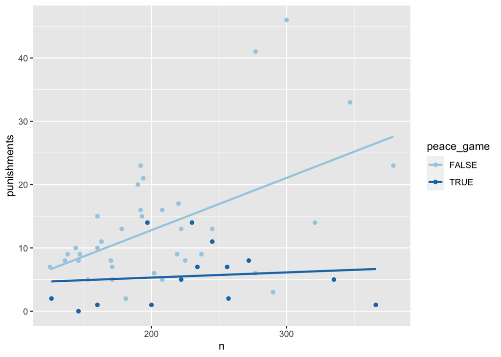

```r
# Number of obs
netdata1 %>%
  ggplot(aes(x=n, y=punishments)) +
  geom_point(aes(color = peace_game)) +
  geom_smooth(aes(group = peace_game, color = peace_game),
              method = "lm",
              se = FALSE) +
  scale_color_brewer(palette = "Paired")
```

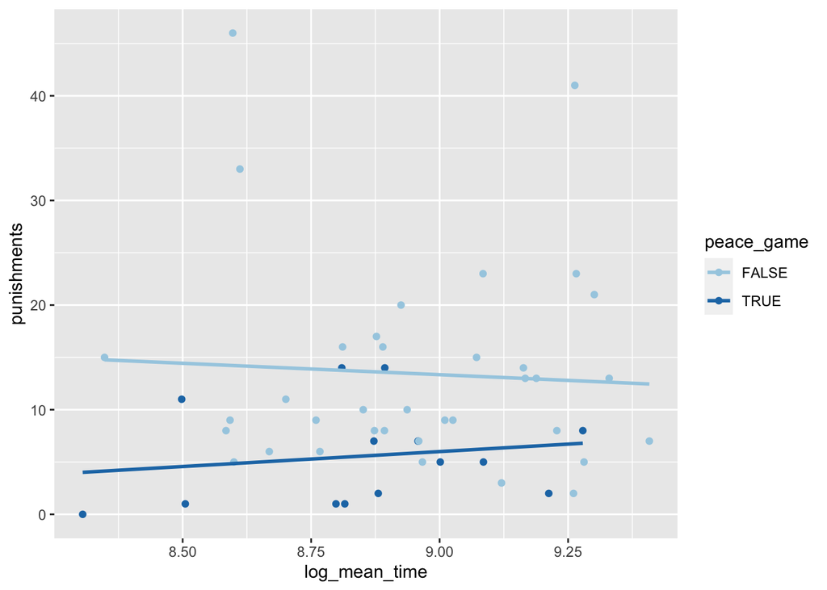

```r
# Log decision time
netdata1 %>%
  ggplot(aes(x=log_mean_time, y = punishments)) +
  geom_point(aes(color = peace_game)) +
  geom_smooth(aes(group = peace_game, color = peace_game),
              method = "lm",
              se = FALSE) +
  scale_color_brewer(palette = "Paired")
```

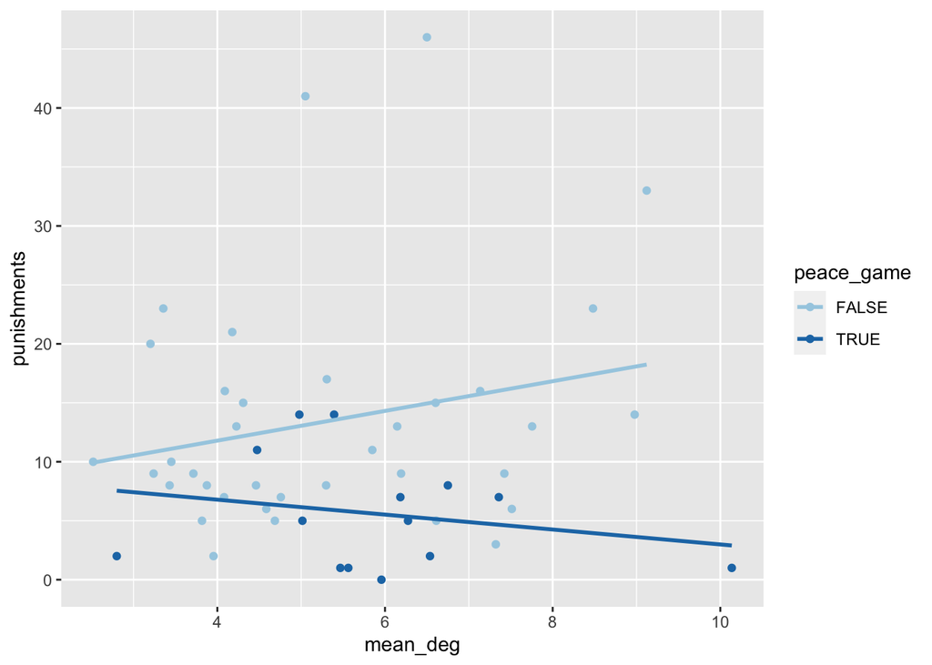

```r
# Mean degree (all rounds)
netdata1 %>%
  ggplot(aes(x=mean_deg, y = punishments)) +
  geom_point(aes(color = peace_game)) +
  geom_smooth(aes(group = peace_game, color = peace_game),
              method = "lm",
              se = FALSE) +
  scale_color_brewer(palette = "Paired")
```

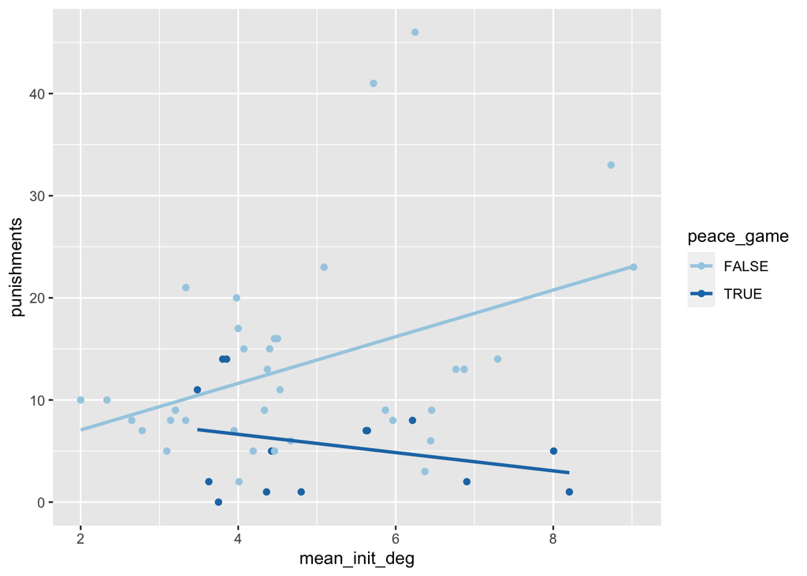

```r
# Initial degree
netdata1 %>%
  ggplot(aes(x=mean_init_deg, y = punishments)) +
  geom_point(aes(color = peace_game)) +
  geom_smooth(aes(group = peace_game, color = peace_game),
              method = "lm",
              se = FALSE) +
  scale_color_brewer(palette = "Paired")
```

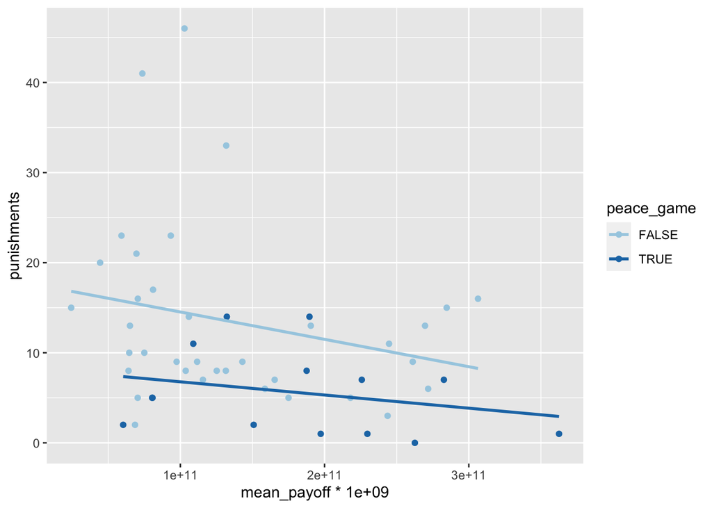

```r
# mean payoff x 10^9
netdata1 %>%
  ggplot(aes(x=mean_payoff*1e9, y = punishments)) +
  geom_point(aes(color = peace_game)) +
  geom_smooth(aes(group = peace_game, color = peace_game),
              method = "lm",
              se = FALSE) +
  scale_color_brewer(palette = "Paired")
```

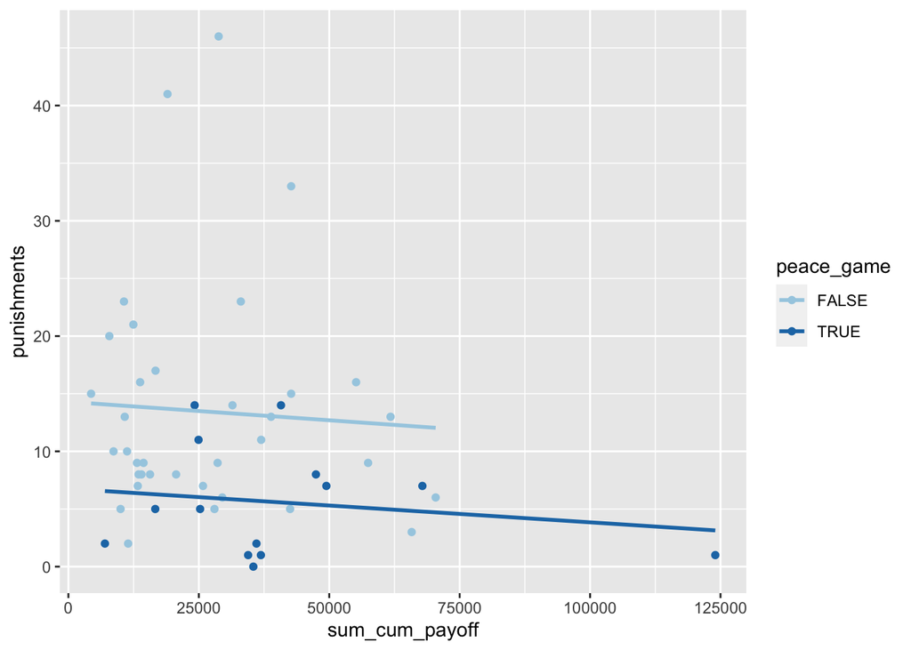

```r
# total payoff
netdata1 %>%
  ggplot(aes(x=sum_cum_payoff, y = punishments)) +
  geom_point(aes(color = peace_game)) +
  geom_smooth(aes(group = peace_game, color = peace_game),
              method = "lm",
              se = FALSE) +
  scale_color_brewer(palette = "Paired")
```

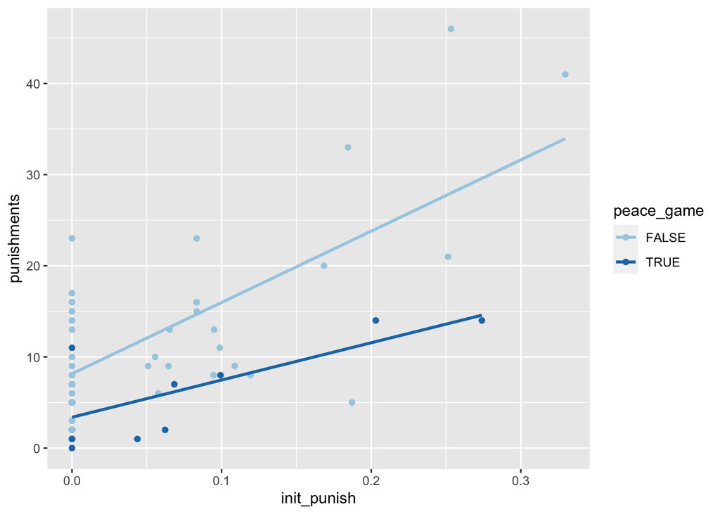

```r
# initial punish proportion
netdata1 %>%
  ggplot(aes(x=init_punish, y = punishments)) +
  geom_point(aes(color = peace_game)) +
  geom_smooth(aes(group = peace_game, color = peace_game),
              method = "lm",
              se = FALSE) +
  scale_color_brewer(palette = "Paired")
```

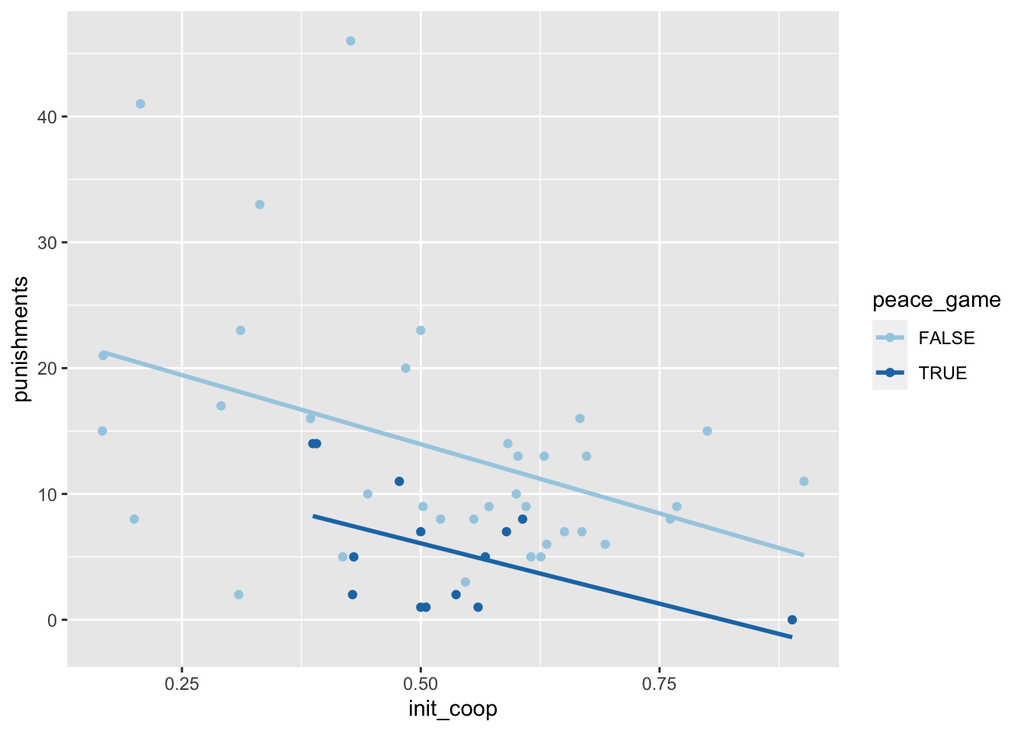

```r
# initial coop proportion
netdata1 %>%
  ggplot(aes(x=init_coop, y = punishments)) +
  geom_point(aes(color = peace_game)) +
  geom_smooth(aes(group = peace_game, color = peace_game),
              method = "lm",
              se = FALSE) +
  scale_color_brewer(palette = "Paired")
```

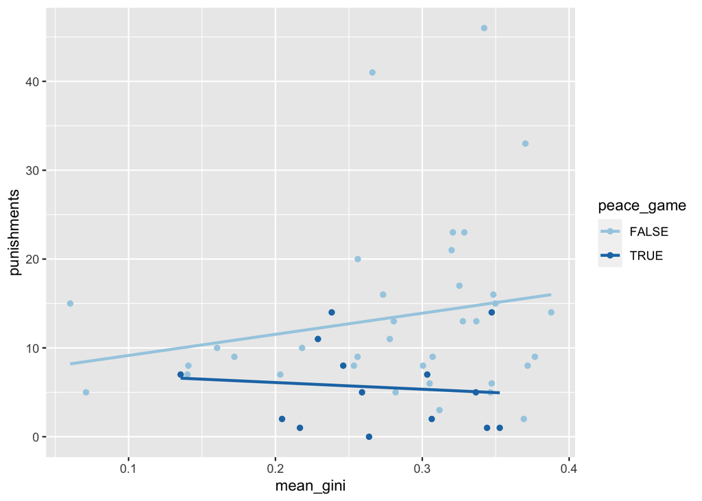

```r
# mean gini
netdata1 %>%
  ggplot(aes(x=mean_gini, y = punishments)) +
  geom_point(aes(color = peace_game)) +
  geom_smooth(aes(group = peace_game, color = peace_game),
              method = "lm",
              se = FALSE) +
  scale_color_brewer(palette = "Paired")
```

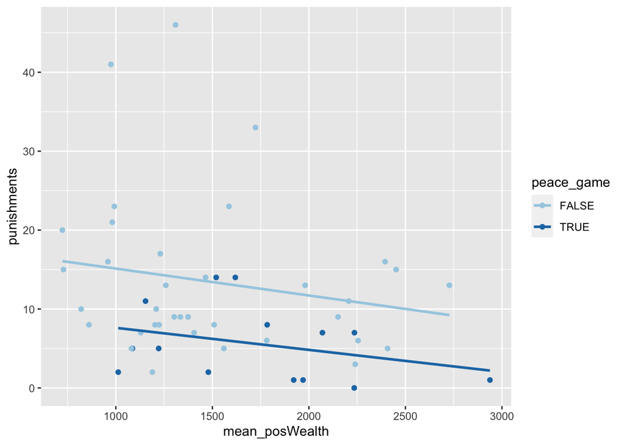

```r
# mean Wealth
netdata1 %>%
  ggplot(aes(x=mean_posWealth, y = punishments)) +
  geom_point(aes(color = peace_game)) +
  geom_smooth(aes(group = peace_game, color = peace_game),
              method = "lm",
              se = FALSE) +
  scale_color_brewer(palette = "Paired")
```